**CS4515** - 3D Computer Graphics and Animation

Elmar Eisemann, Ricardo Marroqium

# Physics Simulation

## Introduction

In this assignment, we will be (ab)using the graphics pipeline to do something *other* than graphics. Namely, we will be harnessing the parallel processing power of the GPU to efficiently compute a particle physics simulation.

The description is separated in three parts to make it easier for you to track your progress.

In Part 1 we will write shader code that computes the position and velocity of every particle for each timestep of our simulation. Following this, we will do collision detection to ensure that our particles remain inside a spherical container. Lastly, we will do collision detection with other particles to make sure that particles bounce off each other instead of traversing them.

In Part 2, we will modify the code used to visualise our particles in a more informative way. We will color particles based on their speed and add simple shading to provide a sense of depth.

Finally, in Part 3, we will make our particles blink after collisions. This will round off our simulation with a nice bit of visual flourish.

Reference videos for some tasks will be posted in Brightspace.

## Initial GUI Overview

Upon launching the application, you will be greeted with the following GUI. You can modify the parameters that are passed to your simulation code (as uniforms) and setup the corresponding UI elements. Further, you can modify properties of the container (see Task 1.2). You can also move the camera around similarly to the shadow mapping assignment. Use your mouse to look around. Use WASD, C, and the space bar to move. Lastly, note that the number that you set for the ‘New particle count’ will only take effect after you click the ‘Reset simulation’ button.

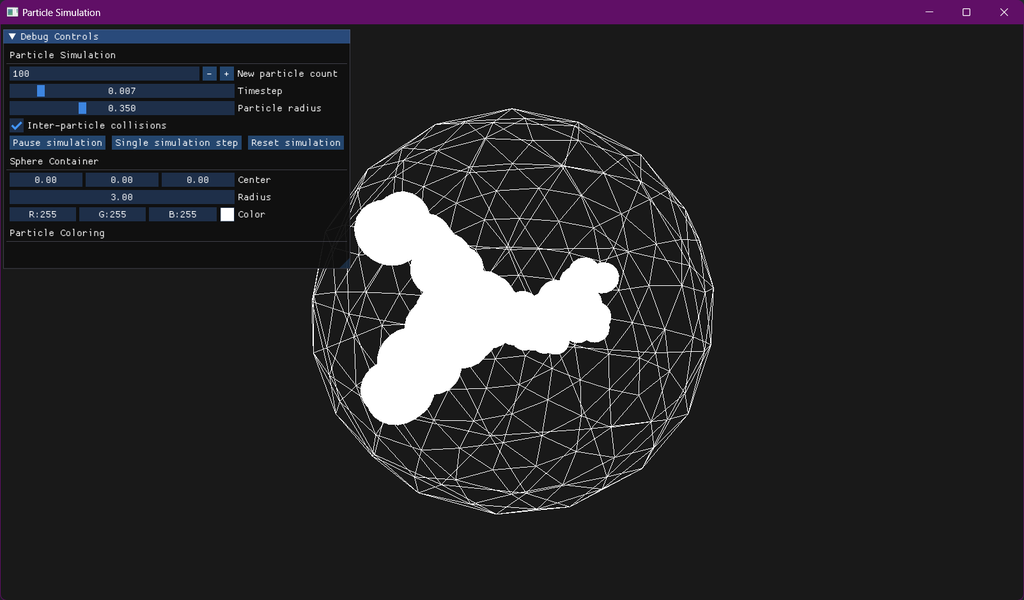

*Initial GUI of the application. You can access different controls to debug and play around with your simulation implementation.*

## Part 1: Simulation

### Preliminaries

#### Files To Modify

For this part, you should work on the following file(s):

- `shaders/simulation/particle-sim.frag`

#### Graphics Pipeline Hijacking

Recall the structure of the graphics pipeline. Essentially, we provide as input to the GPU a number of vertices. These vertices are processed in the vertex shader and their location on the screen is computed using the MVP (model-view-projection) matrix. A number of primitives (usually triangles) are then generated based on the vertex positions. The rasterizer then figures out which pixels on the screen are inside each of these primitives. A fragment shader then does a computation for each of those pixels (fragments) that lie inside a primitive.

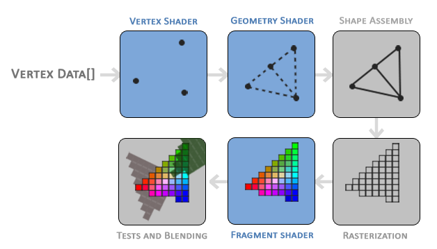

*Structure of the graphics pipeline. [[1]](https://learnopengl.com/Getting-started/Hello-Triangle)*

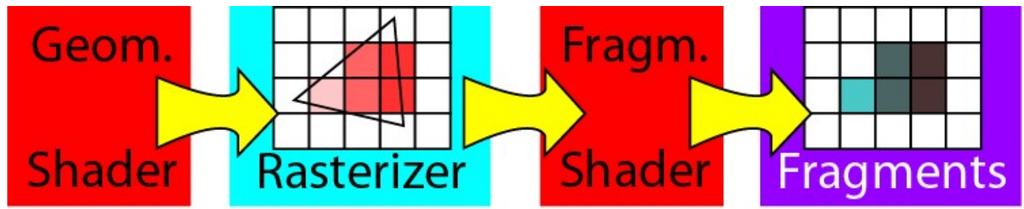

*Role of the fragment shader in the graphics pipeline. It uses the attributes generated by the rasterizer to carry out a computation for all the pixels contained within the primitive (which is a triangle in this case).*

For our particle simulation, we need to store two attributes for each of our $N$ particles: position and velocity. Further, we need to store information to keep track of collisions for the blinking effect in Part 3. We will construct six RGB textures of dimensions $(N \times 1)$ that will store:

1. Positions at time $t + \Delta t$
2. Positions at time $t$
3. Velocities at time $t + \Delta t$
4. Velocities at time $t$
5. Collision data at time $t + \Delta t$
6. Collision data at time $t$

Each one of these textures will look roughly like the following figure. Instead of interpreting the RGB values of the pixels/texels as colors, we will interpret them as $(x, y, z)$ values that encode position, velocity, or bounce information. Note that the collision data is only used in Task 3.

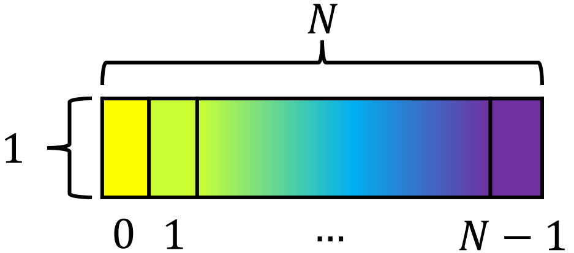

If we then draw a rectangle which maps to the entire texture, this will then produce a number of fragments equal to the number of the texture’s pixels (texels). Effectively, this will run our fragment shader for each of the $N$ texels.

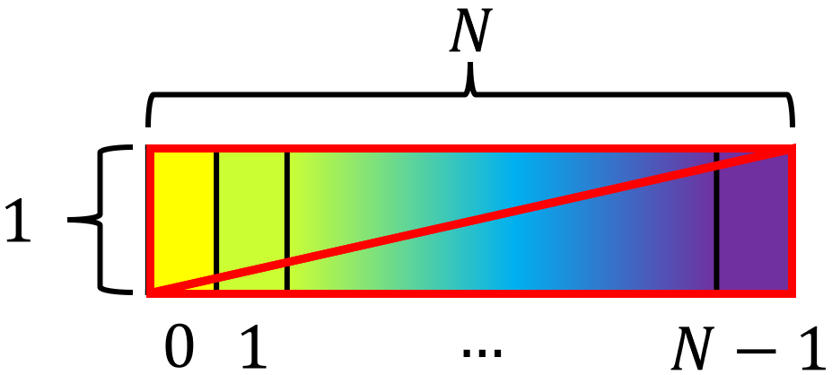

This is exactly what we need to simulate our $N$ particles: the fragment shader will compute the new position, velocity and collision data for each particle, and then ‘render’ the results to our position, velocity, and collision data textures. Graphics APIs like OpenGL allow us to render to textures instead of the screen; we effectively treat our output texture as if it was the screen. Lastly, these APIs also allow us to render to multiple textures at once, so we only need a single fragment shader to compute all three of our new position, new velocity, and new collision data.

#### Ping-Pong Buffers/Textures

Our computations require knowing particular values at a certain iteration and then using those values to compute new values at the next iteration. A popular approach for organising data transfer of this fashion is to use ping-pong buffers/textures (which are a specific case of [multiple buffering](https://en.wikipedia.org/wiki/Multiple_buffering#Double_buffering_in_computer_graphics)). It is commonly used for post-processing effects which require multiple iterations of the same operation, such as blur for motion blur and [bloom](https://learnopengl.com/Advanced-Lighting/Bloom).

With ping-pong buffers, we use one buffer as our source (which holds values at the current iteration) and the other buffer as our destination (which will hold the new values computed in the next iteration). After each iteration, we swap the designation of our buffers. Thus, the newly computed destination buffer will be used as the source buffer for the next iteration. Our data is tossed around like a ping-pong ball between our two buffers, hence the name!

A potential advantage of this approach is that we can separate our physics update rate from our main rendering framerate. One thread can dispatch commands to our GPU to output simulation results to our destination buffer while our main rendering thread can access the data in the source buffer, which the simulation will not modify. For this assignment however, our simulation and main rendering happen on the same thread. This is not a best practice (as people on various videogame forums will be happy to tell you), but it simplifies the assignment. Note that this means that **our simulation results will be framerate-dependent!** Practically, this means that your results may vary from the references based on how powerful your GPU is and your monitor’s refresh rate (as we use V-sync by default in this assignment). **The reference videos were all recorded at a fixed framerate of 60FPS using the default simulation parameters.**

### Task 1.1: Verlet Integration

To simulate the motion of the particles, we use a process known as Verlet Integration, which is an approximate solution to the kinematic equation that is popular for scenarios requiring fast and approximate physics simulations, such as games [[2]](https://www.algorithm-archive.org/contents/verlet_integration/verlet_integration.html). Essentially, we compute the position $x_{t + \Delta t}$, velocity $v_{t + \Delta t}$, and acceleration $a_{t + \Delta t}$ at a new timestep $t + \Delta t$ based on their values at the previous timestep $t$. We use the Velocity Verlet variant of Verlet Integration. We compute these new values as follows:

$$\begin{align*}
x_{t + \Delta t} &= x_t + v_t\Delta t + \frac{1}{2}a_t\Delta t^2 \\
a_{t + \Delta t} &= f(x_{t + \Delta t}) \\
v_{t + \Delta t} &= v_t + \frac{1}{2}(a_t + a_{t + \Delta t})\Delta t
\end{align*}$$

You might recall similar equations from high school physics class, as these are simply the [equations of motion under constant acceleration](https://en.wikipedia.org/wiki/Equations_of_motion#Uniform_acceleration) with a discrete timestep.

Your first task is to compute the new position and velocity of each particle based on its values from the previous timestamp. You can access these values through the `previousPositions` and `previousVelocities` texture samplers. To facilitate this, you may wish to use the [`gl_FragCoord` built-in variable](https://registry.khronos.org/OpenGL-Refpages/gl4/html/gl_FragCoord.xhtml) (additional information here). We assume a constant acceleration due to gravity with a value of 9.81 in the negative y-axis direction. Lastly, recall that the coordinates used to sample textures are in the range [0..1].

### Task 1.2: Container Collision

We now start to make our simulation much more visually interesting. We confine our particles within the wireframe spherical container that you’ve been seeing (and probably ignoring) thus far. Your next task is to check if the particles have collided with the container and adjust their position and velocity accordingly.

For the position, we will push the particle towards the center of the container. For this you need to update the position you computed previously (i.e. use the `+=` operator). You may wish to add a small (relative) offset to the distance that you push the particle by. This is to prevent particles from immediately registering a new collision in the next simulation iteration.

To facilitate this, you are provided with the position of the container `containerCenter`, the radius of the container `containerRadius`, and the radius of the particles `particleRadius` (all particles have the same size). The following figure depicts this

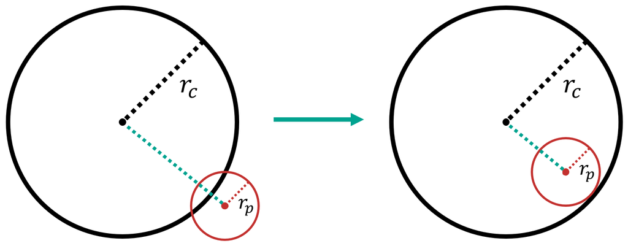

For the velocity, we model our collision with the container as a fully energy-conserving collision. We can decompose the velocity of the particle into two components: one that is parallel to the normal at the point of collision, and one that is perpendicular to it. The part that is parallel to the normal is reversed due to the collision. We use the point where the particle just barely ‘touches’ the container after its position has been adjusted (see the previous paragraph) as an approximation for the point of collision. Effectively, the velocity is reflected about this normal. The following figure visualises this

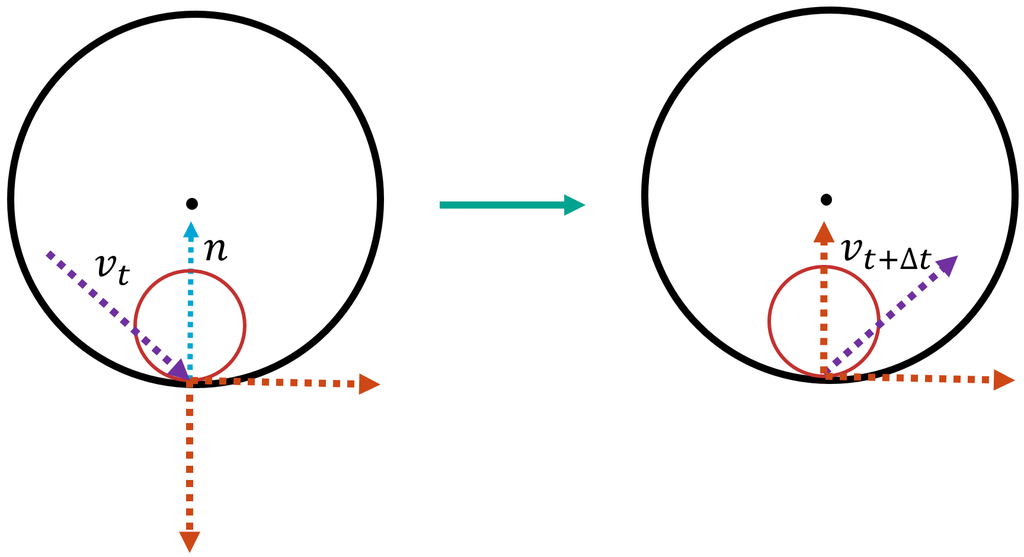

### Task 1.3: Inter-particle Collision

This is where the *real* fun begins. Your final task for this part is to check for collisions with other particles.

We will use a similar logic as with the container collision detection. For every other particle, check if there is a collision. If so, we will nudge our position away from the other particle and reflect our velocity about the normal at the point of collision. We will use the positions of the particles in the last iteration as an approximation for the positions of the other particles.

The collision test will be slighly different, as we want to ensure that particles are not ‘inside’ each other. It might be helpful to visualise a collision before and after the collision is detected. Lastly, be sure not to test for collisions with the same particle!

Note that we conduct the inter-particle collision checks **before the collision check with the container**. This is to ensure that the position and velocity at the end of our shader will definitively not allow for the particle to be outside the container.

## Part 2: Drawing

### Preliminaries

#### Files To Modify

For this part, we will modify the following file(s):

- `shaders/simulation/particle-draw.frag`: This is the shader that computes the actual final color of the particles
- `src/simulation/particles.cpp`: This is the implementation of the class which manages the particle simulation. We will modify the `ParticlesSimulator::draw` function
- `src/ui/menu.cpp`: This contains the implementation of the class which manages the ImGui controls window. We will define the `Menu::drawParticleColorControls` function
- `src/utils/config.h`: This contains the definition of the configuration struct which houses parameters and variables indicating state. We will add some members to the `Config` struct to use for drawing the particles. They will be modified by the GUI and passed along to the shader as uniforms

#### Instanced Rendering

Most of the drawing we have been doing in the assignments thus far was on a per-object basis. For each object, we ask the GPU to draw it, usually with the following function

```cpp
void glDrawElements(GLenum mode, GLsizei count, GLenum type, const void * indices);
```

If we want to draw many of the same object, say 25 particles, we would have to issue 25 draw calls! This would introduce a large amount of communication overhead between the CPU and GPU, harming performance.

Luckily, if our objects are largely the same (e.g. use the same model) and differ in only a few aspects (e.g. have different positions) such as our particles, we can draw all of them in a single draw call. This approach is known as [instanced rendering](https://learnopengl.com/Advanced-OpenGL/Instancing) and is what allows 3D applications such as games to performantly draw many ‘instances’ of the same object (e.g. fire particles or buildings) which are largely similar. In OpenGL, this is accomplished with the following function

```cpp
void glDrawElementsInstanced(GLenum mode, GLsizei count, GLenum type, const void * indices, GLsizei instanceCount);
```

### Task 2.1: Speed-based Colors

Your first task for this part is to color our particles based on their speed. You should define two user-adjustable colors that correspond to a speed of zero and a user-defined maximum speed. Linearly interpolate between the two based on the particle’s speed. All particles whose speeds are greater than or equal to the maximum speed should be colored with the maximum speed color. You should be able to toggle between a user-adjustable pre-set color and the velocity-based color.

You should modify the `Config` struct to store the variables you need. Define the `Menu::drawParticleColorControls` function to obtain the data you need from the user via the GUI (the definition of `Menu::drawSphereContainerControls` in the same file might give you some inspiration). Modify the `ParticlesSimulator::draw` function to pass the newly defined variables to your shader as uniforms. Finally, combine this data in the `particle-draw.frag` fragment shader to compute the particle’s final color.

### Task 2.2: Shading

Your second and final task for this part is to implement basic shading. Use the color produced by the previous task as the base color for a simple [Phong](https://en.wikipedia.org/wiki/Phong_reflection_model)-esque shading model consisting of two terms:

1. An ambient term with a user-adjustable coefficient
2. A diffuse term based on a single (non-shadow-casting) light at the center of the container

You should include a toggle in the GUI to turn this shading on or off.

## Part 3: Blinking

### Preliminaries

#### Files To Modify

In this part, you will implement a new simulation feature alongside its UI controls and corresponding visualisation. Hence, you will decide the ideal corresponding code structure yourself and so the exact files and methods you need to modify are not specified. You **mostly** only need to modify files which you have already modified in previous parts. However, you may need to create or modify different functions!

#### Swizzling

For this part, we make use of swizzling. You have likely already used this for the previous parts as well as previous assignments. Given a vector type in GLSL (the language in which OpenGL shaders are written), we can access its individual components using swizzle masks. There are three equivalent sets you can use: `xyzw`, `rgba`, and `stpq`.

```
vec4 homogeneous = vec4(1.0f, 2.0f, 3.0f, 4.0f);
homogeneous.x; // 1.0f;
homogeneous.r; // 1.0f;
homogeneous.s; // 1.0f;
homogeneous.w; // 4.0f;
homogeneous.a; // 4.0f;
homogeneous.q; // 4.0f;
```

You can even use combinations of swizzling masks to produce new vector types

```
homogeneous.xyz; // vec3(1.0f, 2.0f, 3.0f);
homogeneous.gg; // vec2(2.0f, 2.0f);
```

### Task 3.1: Bounce Blinks

This is the only task for this part and consists of implementing a collision blinking feature from start to finish. We will make use of the collision data texture to keep track of two values (we do not need to use the third component of the texels):

1. The number of collisions that a particle has encountered. This value is stored in the $x$ component of each texel.
2. The number of simulation iterations/frames that a particle should maintain a ‘blink color’ for. This value will be stored in the $y$ component of each texel.

Every time a particle encounters a collision, increment the first value (the collision counter). Once the counter exceeds a user-specified threshold, set the second value (the frame counter) to a user-specified value and reset the collision counter to zero. The threshold represents the number of collisions a particle must encounter before it blinks. The second user-specified value represents the number of simulation iterations/frames that the blink will last for.

Decrement the frame counter every simulation iteration/frame. Make sure this value does not go below zero! If the frame counter is greater than zero, set the particles to a user-defined color. If shading is enabled, this color should be used as the base color, similarly to Task 2.2. This color takes precedence over the velocity color if it should be used. Lastly, include a toggle to enable or disable using this color, similarly to the toggle from Task 2.1.

All user-specified values should be adjustable via the GUI. The reference video for this task was recorded using only two particles to make it easier to observe the blinking behaviour. All other parameters remain at their default values and the recording conditions are the same as previous tasks.

## Fun Extras

The information in this section is **not a part of the assignment** and knowledge of it will **not be assessed**. This section is meant for students who found this assignment and/or the idea of doing general-purpose computation on GPUs to be interesting and would like additional resources to expand their knowledge.

### Compute Shaders

As GPUs can allow for immense speedups for computations that can be parallelised, an easier way to leverage them for general-purpose computation was deemed necessary by GPU manufacturers and graphics API developers. To this end, compute shaders were introduced by most graphics APIs and have since been adopted by various industries for diverse applications. Examples include:

- Graphics workloads that do not consist of putting triangles on a screen. Compute shaders are **everywhere** in real-time *and* offline computer graphics
- Training machine learning models, as this process usually consists of many parallel matrix-matrix multiplications
- Physics simulations

In a nutshell, a compute shader allows you to provide arbitrary data to the GPU and perform computations on it without having to use the full graphics pipeline. This data can be in the form of buffers or textures. Two useful resources for learning about compute shaders are

1. [The LearnOpenGL compute shader introduction article](https://learnopengl.com/Guest-Articles/2022/Compute-Shaders/Introduction)
2. [Lecture 20 - Compute & Mesh Shaders](https://www.youtube.com/watch?v=HH-9nfceXFw) from the course [CS6610 Interactive Computer Graphics](https://graphics.cs.utah.edu/courses/cs6610/spring2024/) by the University of Utah (yes, the teapot guys)

### Vulkan Compute Exercises

You may have heard of a fancy new graphics API by the name of Vulkan. It was introduced by The Khronos Group (the same people that maintain OpenGL) in 2016 and (alongside the very similar DirectX 12) has been gradually adopted as a replacement for older APIs like OpenGL (which has been around since 1992) and DirectX <=11.

It offers more granular control over the GPU compared to older APIs and exposes you to more of the GPU’s actual parallel processing nature, allowing for potentially greater performance. Further, it allows you to make use of features on newer graphics cards such as [hardware-accelerated ray-tracing](https://www.khronos.org/blog/ray-tracing-in-vulkan) and [mesh shaders](https://www.khronos.org/blog/mesh-shading-for-vulkan) which are inaccessible on older APIs. However, it is infamous for being [notoriously verbose and difficult to learn](https://www.jeremyong.com/c++/vulkan/graphics/rendering/2018/03/26/how-to-learn-vulkan/). You will find [many](https://www.reddit.com/r/gamedev/comments/179pqq6/vulkan_is_miserable/), [*many*](https://news.ycombinator.com/item?id=34357322), [*many*](https://www.reddit.com/r/vulkan/comments/efcb6w/how_can_i_get_through_the_25k_lines_of/) painful accounts of its verbosity, *especially* for people without much prior computer graphics experience.

However, using Vulkan for compute is **significantly** simpler and requires a fraction of the boilerplate needed for setting up a full graphics pipeline. If you would like to learn more about compute shaders and/or Vulkan, you can try to tackle [these Vulkan compute exercises](https://github.com/bkerbl/vulkan-compute-exercises) made by lecturers from TU Wien. These exercises were part of a workshop presented at the 2023 iteration of the High Performance Graphics conference, which was held right here in TU Delft! You can find the corresponding presentation recording [here](https://www.youtube.com/watch?v=nD83r06b5NE) and slide deck [here](https://1drv.ms/b/s!AugrsMpnQDQZgupa2C6tBbbQczrfng?e=EoebNg). The exercises start by introducing you to the API and how to initialise it and end with a number of interesting **GP-GPU (General Purpose GPU)** programs such as an image edge detector, a point cloud renderer, and matrix-matrix multiplication.

## References

- [1] Joey de Vries, LearnOpenGL - Getting Started - Hello Triangle, https://learnopengl.com/Getting-started/Hello-Triangle
- [2] James Schloss, Verlet Integration, https://www.algorithm-archive.org/contents/verlet_integration/verlet_integration.html

# Submission

You should submit your code to Brightspace before the assigned deadline. Please make sure to **not** submit your build folder or any executables.

During the practical session on Friday October 17th a TA or lecturer will check you out.

## Check-out

During the check-out you will run your application from your computer. Make sure you have it compiled and ready to run. You will then be asked to follow some instructions to test your application. Make sure you can control all parameters described in the tasks above from your UI.

## Grading

Your grade for this deliverable is determined by the check-out procedure and a follow-up inspection of the code. In some cases, you may be called for further discussion with the course staff.

The grade of Assignment 1 is composed of three parts. This current deliverable is **Part 2** and is worth 1/4 of the Assignment 1 grade, which is equivalent to 15% of the Final Grade of the course.

As a reminder: to pass the course you need to achieve at least 5.0 in each Assignment 1 and Assignment 2 grades, and your final rounded grade should be at least 6.0.